# POLSCI 672 Lab: Getting Started II

Author

Chern Xun Gan

Published

September 4, 2026

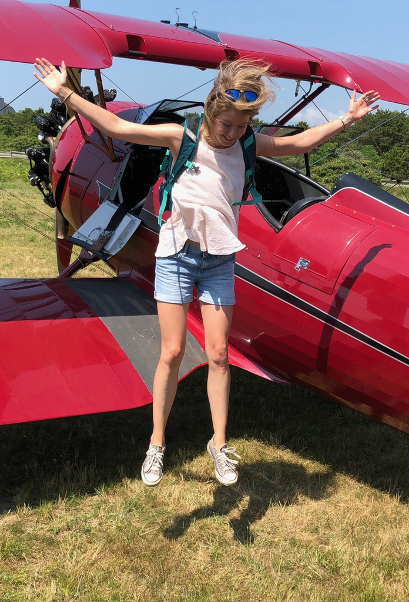

Representative study participant jumping from aircraft with an empty backpack, From Yeh, Robert W, et. al., “Parachute use to prevent death and major trauma when jumping from aircraft: randomized controlled trial,” *BMJ* (2018).

## Modelling with `estimatr`

`estimatr` is a family of functions that allows us to do regressions that will be used in this class. We will explore it with the `caffeine` data from last week.

```r
# load required packages
library(tidyverse)
library(estimatr)

# import data
load("caffeine.Rdata")

# clean data (remove missing observations)
caffeine <-
  caffeine %>%
  sapply(as.numeric) %>%
  as.data.frame() %>%
  na.omit()
```

For now, we just need to know about `lm_robust()`. This function is similar to the base R `lm()` function and conducts OLS regression, but it provides robust standard errors.

```r
# regress score ~ matcha
m1 <- caffeine %>%
  lm_robust(score ~ ., .)

summary(m1)
```

```
Call:
lm_robust(formula = score ~ ., data = .)

Standard error type:  HC2

Coefficients:
            Estimate Std. Error  t value  Pr(>|t|) CI Lower CI Upper  DF
(Intercept)  2.53333     0.2391 10.59502 1.837e-19   2.0605   3.0062 135
matcha       0.03188     0.3403  0.09371 9.255e-01  -0.6410   0.7048 135
coffee       0.80709     0.3333  2.42160 1.678e-02   0.1479   1.4662 135

Multiple R-squared:  0.0524 ,   Adjusted R-squared:  0.03836
F-statistic: 3.784 on 2 and 135 DF,  p-value: 0.02519
```

**Advanced piping**

When you do not wish to pipe the LHS into the first argument of the RHS, or if you wish to use the LHS as an expression for an argument in the RHS, use periods “`.`” to indicate where the LHS should go.

```r
# referencing a variable using pipes
caffeine %>%
  .$coffee %>%
  head()
```

```
[1] 1 0 0 1 1 1
```

### Producing neat tables with `kable`

`kable()` allows us to turn R data frames and matrices into neat tables for R Markdown PDFs. Let us try to turn the regression output into a neat table.

Before we use `kable()`, take a look at the help file for that function. What kind of input can `kable()` take in the first argument? It says it should be a matrix or data frame. However, what type of object is our regression output, `m1`?

Fortunately, `tidy()` is a function that can easily convert outputs from `estimatr` to a tibble (the `tidyverse` version of data frames). We should pass `m1` into `tidy()` first, before producing a table with it using `kable()`.

```r
# load package
library(knitr)

# tidy m1 into data frame to print
m1 %>%
  tidy() %>%
  kable()
```

| term | estimate | std.error | statistic | p.value | conf.low | conf.high | df | outcome |
| --- | --- | --- | --- | --- | --- | --- | --- | --- |
| (Intercept) | 2.5333333 | 0.2391061 | 10.5950185 | 0.0000000 | 2.0604551 | 3.006212 | 135 | score |
| matcha | 0.0318841 | 0.3402541 | 0.0937066 | 0.9254812 | -0.6410338 | 0.704802 | 135 | score |
| coffee | 0.8070922 | 0.3332891 | 2.4215981 | 0.0167804 | 0.1479490 | 1.466235 | 135 | score |

It looks fine, but we can do better. Let us try to do a few things:

- rename columns
- reduce the number of digits displayed
- remove the last 2 columns
- add a caption

```r
m1 %>%
  tidy() %>%
  select(-(last_col(offset = 1):last_col())) %>%
  kable(
   digits = 3, ## limit to 3 decimal places
   col.names = c("Term", "Estimate", "SE", "Statistic", "p-value", "5%", "95%"),
   caption = "OLS results of problem set score on caffeine use"
  )
```

OLS results of problem set score on caffeine use

| Term | Estimate | SE | Statistic | p-value | 5% | 95% |
| --- | --- | --- | --- | --- | --- | --- |
| (Intercept) | 2.533 | 0.239 | 10.595 | 0.000 | 2.060 | 3.006 |
| matcha | 0.032 | 0.340 | 0.094 | 0.925 | -0.641 | 0.705 |
| coffee | 0.807 | 0.333 | 2.422 | 0.017 | 0.148 | 1.466 |

### Printing regression tables

The `texreg` package provides a neat way to produce regression tables, and can support including multiple models in a table. There are other packages, such as `stargazer`, that do the same. Use `texreg()` for $\LaTeX$ output. `knitreg()` will automatically select the right output for your document type.

```r
library(texreg)

knitreg(m1,
        custom.model.names = "Problem set score",
        caption = "OLS results of problem set score on caffeine use")
```

OLS results of problem set score on caffeine use

|  | Problem set score |
| --- | --- |
| (Intercept) | 2.53* |
|  | [ 2.06; 3.01] |
| matcha | 0.03 |
|  | [-0.64; 0.70] |
| coffee | 0.81* |
|  | [ 0.15; 1.47] |
| R<sup>2</sup> | 0.05 |
| Adj. R<sup>2</sup> | 0.04 |
| Num. obs. | 138 |
| RMSE | 1.61 |

* 0 outside the confidence interval.

### `estimatr` integration with `ggplot2`

Instead of `geom_smooth()`, we may want to try using robust variance estimates for drawing confidence intervals

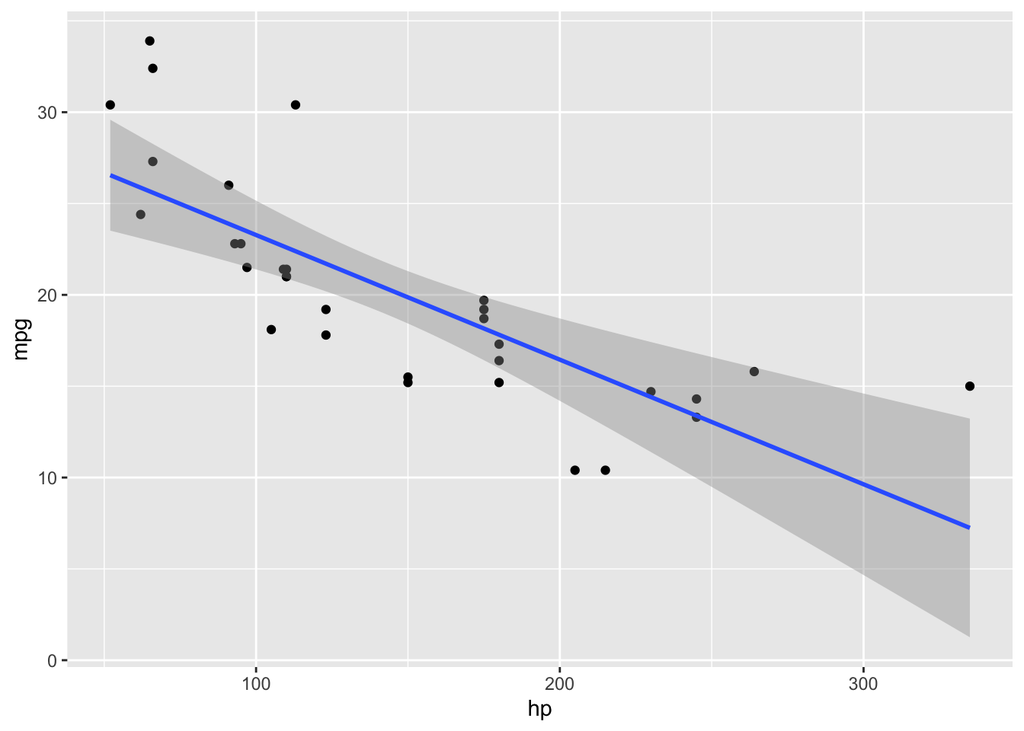

```r
mtcars %>%
  ggplot(mapping = aes(x = hp, y = mpg)) +
  geom_point() +
  stat_smooth(method = "lm_robust")
```

## Some useful functions to simplify operations

In addition to the usual data management functions and packages we have covered so far, there are two additional operations that we might use regularly for this class. In many cases, it is not required that you use them, but it will make things quicker.

For these 2 operations, I will introduce both a base R function and a function from `tidyverse`. The difference of the functions is essentially syntax. You may find, for example, that it is more convenient to stay within the `tidyverse` world. I encourage you to check the help files for these functions to see how to best use them.

### Applying function over lists or vectors: `lapply()` or `map()`

These functions achieve similar tasks as for-loops. If you wish to run elements of a list or vector over the same function, then produce the output in a list or vector, these families of functions may be more convenient to use. `lapply()` is the base R family, while `map()` is the equivalent in `purrr` (a `tidyverse` package).

Note that several functions exist under these 2 families of functions. Please consult the help files of those functions to see which specific functions may best suit your needs. For our purposes, we generally can stick to using `lapply()` or `map()` for list outputs or `sapply()` and `map_vec()` for vector outputs.

Let us start with something simple. For the sake of demonstration, say we have a vector $<1, 2, 3>$ and we wish to add 1 to it.

```r
# using lapply to produce a list
c(1, 2, 3) %>%
  lapply(function(x) {x + 1})
```

```
[[1]]
[1] 2

[[2]]
[1] 3

[[3]]
[1] 4
```

```r
# using sapply to produce a vector
c(1, 2, 3) %>%
  sapply(function(x) {x + 1})
```

```
[1] 2 3 4
```

```r
# using map to produce a list
c(1, 2, 3) %>%
  map(~ . + 1)
```

```
[[1]]
[1] 2

[[2]]
[1] 3

[[3]]
[1] 4
```

```r
# using map_vec to produce a vector
c(1, 2, 3) %>%
  map_vec(~ . + 1)
```

```
[1] 2 3 4
```

Notice the syntax differences when using `lapply()` versus `map()`.

These functions are most useful when the input is a list. Let us use them to find the means of each of the 3 variables in `caffeine`.

When we enter `caffeine` (a data frame) into the first argument, the functions will coerce `caffeine` into a list.

```r
# preview how the data frame looks like as a list
caffeine %>%
  head() %>%
  as.list()
```

```
$matcha
[1] 0 0 0 0 0 0

$coffee
[1] 1 0 0 1 1 1

$score
[1] 6 4 2 3 4 5

attr(,"na.action")
  6  22  40  42  55  79  80 100 110 113 121 136
  6  22  40  42  55  79  80 100 110 113 121 136
attr(,"class")
[1] "omit"
```

```r
# find means of each column in data frame
caffeine %>%
  lapply(mean)
```

```
$matcha
[1] 0.3333333

$coffee
[1] 0.3405797

$score
[1] 2.818841
```

```r
# equivalently
caffeine %>%
  map(mean)
```

```
$matcha
[1] 0.3333333

$coffee
[1] 0.3405797

$score
[1] 2.818841
```

We can also use these functions to perform manipulations on lists. Let’s say we wish to extract the fifth element of all 3 variables in `caffeine`.

```r
caffeine %>%
  lapply(function (x) {x[[5]]})
```

```
$matcha
[1] 0

$coffee
[1] 1

$score
[1] 4
```

```r
caffeine %>%
  lapply(`[[`, 5)
```

```
$matcha
[1] 0

$coffee
[1] 1

$score
[1] 4
```

```r
caffeine %>%
  map(5)
```

```
$matcha
[1] 0

$coffee
[1] 1

$score
[1] 4
```

```r
caffeine %>%
  map(function (x) {x[[5]]})
```

```
$matcha
[1] 0

$coffee
[1] 1

$score
[1] 4
```

Note also that the syntax used in `lapply()` where the second argument must be a function can also be used in `map()`!

### Splitting data: `split()` or `group_split()`

We previously learned to use `group_by()` with `summarize()` to produce grouped summaries of data. Please see Week 1 lab notes for a brief guide on what occurs on the back end when you use `group_by()`.

Often, we may wish to split data into groups and perform functions over the data that way. This is almost exactly what we achieved with `group_by()`. However, `group_by()` can only be used in conjunction with certain `dplyr` functions such as `summarize()` and `mutate()`. To perform a similar operation using other functions, we use the base R `split()` or its `dplyr` equivalent `group_split()`.

Let us split the `caffeine` data into two sets, one with `coffee == 0` and `coffee == 1`.

```r
# I am including head() here just to shorten the output
caffeine %>%
  head() %>%
  split(~ .$coffee)
```

```
$`0`
  matcha coffee score
2      0      0     4
3      0      0     2

$`1`
  matcha coffee score
1      0      1     6
4      0      1     3
5      0      1     4
7      0      1     5
```

```r
caffeine %>%
  head() %>%
  group_split(coffee)
```

```
<list_of<
  tbl_df<
    matcha: double
    coffee: double
    score : double
  >
>[2]>
[[1]]
# A tibble: 2 × 3
  matcha coffee score
   <dbl>  <dbl> <dbl>
1      0      0     4
2      0      0     2

[[2]]
# A tibble: 4 × 3
  matcha coffee score
   <dbl>  <dbl> <dbl>
1      0      1     6
2      0      1     3
3      0      1     4
4      0      1     5
```

As you can see, `split()` and `group_split()` each returns a list of data frames – perfect to use with `lapply()` and `map()`!

For example, let’s say I wish to find the mean of `score` for `matcha == 0` and `matcha == 1` and output this as a list. We previously did this using `summarize()` and `group_by()` to return a data frame. Let’s produce a list this time.

```r
# using split and map
caffeine %>%
  split(.$matcha) %>%
  map(~mean(.$score))
```

```
$`0`
[1] 2.945652

$`1`
[1] 2.565217
```

```r
# we can mix and match base R and tidyverse functions
caffeine %>%
  group_split(.$matcha) %>%
  lapply(function (x) mean(x$score))
```

```
[[1]]
[1] 2.945652

[[2]]
[1] 2.565217
```

## Exercise: putting it all together

Our goal today is to use what we learnt from lab up till now to plot a graph of the observations in `caffeine` which looks like this:

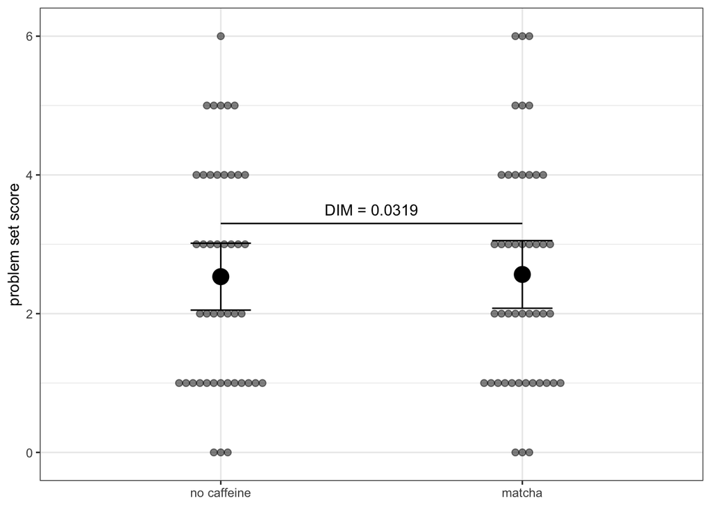

The graph should include the following elements:

1. a dot plot showing the distribution of problem set scores for subjects who received matcha and subjects who did not receive caffeine.
2. error bars showing the mean and 95% confidence intervals for problem set scores for subjects who received matcha and subjects who did not receive caffeine. These error bars should be computed from the standard errors of the means.
3. an annotation of the differences in means in problem set scores for subjects who received matcha and subjects who did not receive caffeine.

**Remember intercept-only models?**

How can we produce intercept-only models in R? Do you remember how to interpret the coefficients of such a model?

## Conditional expectations

For pretty much every chapter in the rest of the course, we will be using conditional expectations in one way or another. We will go through a simpler example here (note: this table is NOT the correct answer to Question 3 on the problem set).

|  |  |  | $Y_i (1)$ |  |
| --- | --- | --- | --- | --- |
|  |  | 15 | 20 | 30 |
|  | 10 | $\frac{1}{7}$ | $\frac{2}{7}$ | $\frac{0}{7}$ |
| $Y_i (0)$ | 15 | $\frac{0}{7}$ | $\frac{1}{7}$ | $\frac{1}{7}$ |
|  | 20 | $\frac{1}{7}$ | $\frac{0}{7}$ | $\frac{1}{7}$ |

$E [Y_i (0) \mid Y_i (1) > 15]$ refers to the expected value of $Y_i (0)$ given that $Y_i (1)$ is greater than 15. In other words, among the subset of observations where the treated potential outcome is greater than 15, what is the weighted average of untreated potential outcomes?

We may compute this conditional expectation through the following formula:
$$E [Y_i (0) \mid Y_i (1) > 15] = \sum_i Y_i (0) \frac{\text{Pr} (Y (0) = Y_i (0), Y_i (1) > 15)}{\text{Pr} (Y_i (1) > 15)}$$

The formula is less complicated than it looks! Let us compute this conditional expectation in a few steps.

1. First, identify the observations that are included in the subset where $Y_i (1) > 15$.
- This corresponds to the two columns, $Y_i (1) = 20$ and $Y_i (1) = 30$.
2. Next, identify the values of $Y_i (0)$ and the corresponding probabilities of encountering each value of $Y_i (0)$ within the subset. Per the formula, the probabilities will be multiplied by the value of $Y_i (0)$.
- $\text{Pr} (Y_i (0) = 10, Y_i (1) > 15) = \frac{2}{7}$
- $\text{Pr} (Y_i (0) = 15, Y_i (1) > 15) = \frac{1}{7} + \frac{1}{7} = \frac{2}{7}$
- $\text{Pr} (Y_i (0) = 20, Y_i (1) > 15) = \frac{1}{7}$
3. The denominator is the total probability that the treated potential outcome is greater than 15, which is also the sum of probabilities in Step 2, that is, $\frac{2}{7} + \frac{2}{7} + \frac{1}{7} = \frac{5}{7}$.

Putting it together,
$$E [Y_i (0) \mid Y_i (1) > 15] = \frac{10 \cdot \frac{2}{7} + 15 \cdot \frac{2}{7} + 20 \cdot \frac{1}{7}}{\frac{5}{7}} = 14$$

There may be alternative ways to compute this conditional expectation that do not rely on the exact formula. Try testing your intuition by employing a different method for the problem set!